# Final Project RFS

We also remove EVs and HF vehicles as they do not contribute to emissions.

```r
car_test <- car_test[, !names(car_test) %in% c("FE.Bag.4","FE.Bag.3","FE.Bag.2","FE.Bag.1")]

car_test_filter <- car_test[car_test$fuel.type != "Electricity", ]
car_test_filter <- car_test_filter[car_test_filter$fuel.type != "Hydrogen 5", ]
levels(car_test_filter$fuel.type)
```

```
## [1] "Cold CO Premium (Tier 2)"
## [2] "Cold CO Regular (Tier 2)"
## [3] "E85 (85% Ethanol 15% EPA Unleaded Gasoline)"
## [4] "Electricity"
## [5] "Federal Cert Diesel 7-15 PPM Sulfur"
## [6] "Hydrogen 5"
## [7] "Tier 2 Cert Gasoline"
## [8] "Tier 3 E10 Premium Gasoline (9 RVP @Low Alt.)"
## [9] "Tier 3 E10 Regular Gasoline (9 RVP @Low Alt.)"
```

```r
car_test_filter$fuel.type <- droplevels(car_test_filter$fuel.type) #drop unused factor levels, ie electricity and hydrogen
levels(car_test_filter$fuel.type)
```

[output not shown]

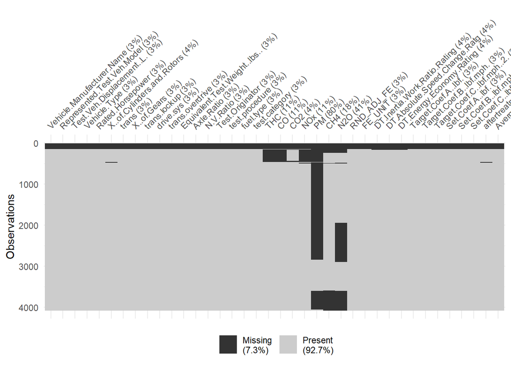

```r
vis_miss(car_test_filter, cluster = TRUE)
```

```r
# from the above visual, let's delete all observations missing vehicle
```

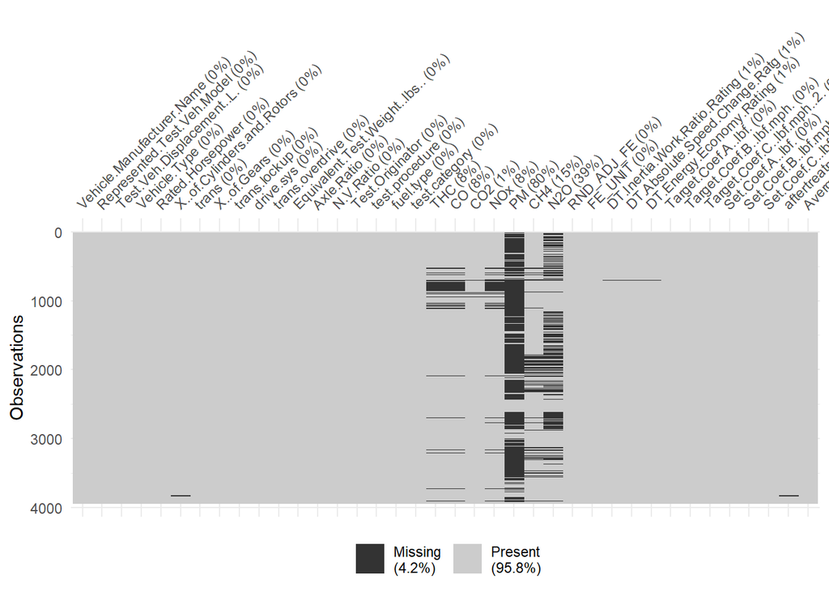

```r
# drop observations that do not have vehicle model
car_test_filter <- car_test_filter[complete.cases(car_test_filter$Vehicle.Manufacturer.Name), ]

vis_miss(car_test_filter, cluster = F)
```

There are two distinct clusters to missingness. The first obvious cluster concerns gases, which comprise majority of the missing data. The next cluster, though marginal, concerns “Rotors and Cylinders”, “DT Ratings” and “Aftertreatment”.

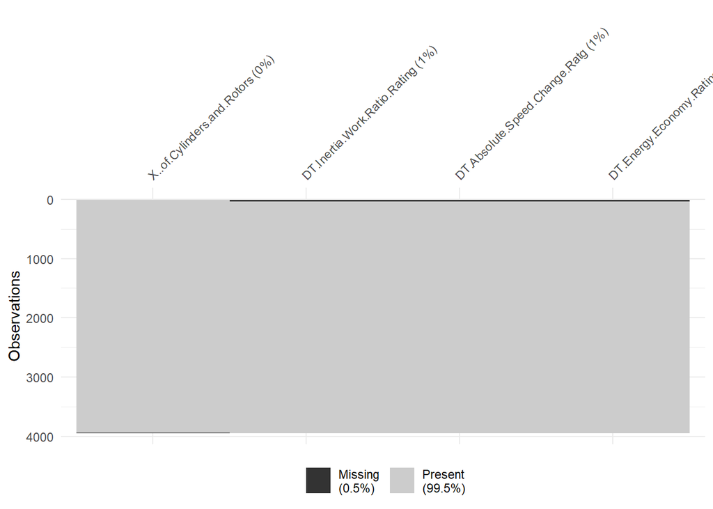

```r
vis_miss(car_test_filter[,c("X..of.Cylinders.and.Rotors","DT.Inertia.Work.Ratio.Rating", "DT.Absolute.Speed.Change.Ratg", "DT.Energy.Economy.Rating")], cluster = T)
```

PM, CH4 and N2O form a major common cluster of missingness. Let’s dive deeper into these variables and note their distributions

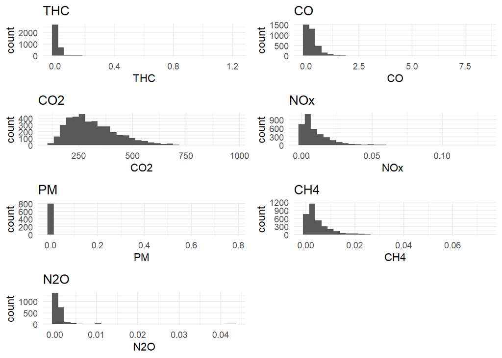

```r
library(ggplot2)
sel_col <- c("THC", "CO", "CO2", "NOx", "PM", "CH4", "N2O")

hist_plots <- list()

for (var in sel_col) {
    hist_plots[[var]] <- ggplot(car_test_filter, aes_string(x = var)) +
    geom_histogram() +
    labs(title = var) +
    theme_minimal()
}
grid <- do.call(gridExtra::grid.arrange, c(hist_plots, ncol = 2))
```

```r
grid
```